# Estudios de Informática, Multimedia y Telecomunicaciones

# Fundamentos de Data Mining - PRÁCTICA COMPLETA

Nicolás Caruso

# 1 Selección de la base de datos

Para esta práctica decidí elegir una base de datos del portal UCI Machine Learning Repository. Se trata de un conjunto de 2126 cardiotocogramas análizados automáticamente en el marco del desarrollo, por parte de investigadores de la Universidad de Porte, de un *software* específico llamado SisPorto 2.0 (Ayres-de-Campos et al. 2000).  
La cardiotocografía (CTG) es un método de evaluacion fetal que registra de manera simultánea la frecuencia cardíaca fetal, los movimientos fetales y las contracciónes uterinas. Este registro, permite al médico valorar el latido cardíaco fetal durante la última etapa de la gestación y la respuesta del bebé a las contracciónes durante el trabajo de parto y hasta el nacimiento. La CTG se utiliza durante el último trimestre con el objetivo de testear si el bebé está sufriendo de hipoxia aguda o crónica y, de no ser así, obtener información acerca del riesgo que tiene el bebé de desarrollar hipoxia antes del nacimiento (Sahin and Subasi 2015).  
Esta base de datos me pareció interesante en primer lugar porque tiene relación con mi formación de base (ciencias biológicas), pero además porque se trata de datos multivariados, en los que el objetivo es predecir el estado del feto en función de ciertas variables fisiológias que se registran mediante la cardiotocografía. Los autores de la base de datos clasifican a los fetos en 3 categorías: normal, sospechoso y patológico. Se trata entonces de una base de datos apta para aplicar algoritmos de clasificación y las técnicas de reducción de dimensiones que se proponen en esta práctica.

# 2 Carga de la base de datos

Comenzamos descargardo la base de datos del portal UCI Machine Learning Repository:

```r
library(readxl)
library(httr)

# URL de la base de datos
url<-"https://archive.ics.uci.edu/ml/machine-learning-databases/00193/CTG.xls"

# obtengo la base de datos de la URL y la guardo en un archivo temporal
GET(url, write_disk(tf <- tempfile(fileext = ".xls")))
```

```
## Response [https://archive.ics.uci.edu/ml/machine-learning-databases/00193/CTG.xls]
##   Date: 2021-01-13 20:17
##   Status: 200
##   Content-Type: application/x-httpd-php
##   Size: 1.74 MB
## <ON DISK>  /tmp/Rtmpn8SAdV/file6814363ce011.xls
```

```r
# leo el archivo temporal con los datos
df <- read_excel(tf, sheet = 3)
```

# 3 Inspección y preparación de los datos

Podemos inspeccionar los datos para ver cómo está conformada la base:

```r
# nombres de las columnas de la base de datos
colnames(df)
```

```
##  [1] "FileName" "Date"     "SegFile"  "b"        "e"        "LBE"
##  [7] "LB"       "AC"       "FM"       "UC"       "ASTV"     "MSTV"
## [13] "ALTV"     "MLTV"     "DL"       "DS"       "DP"       "DR"
## [19] "Width"    "Min"      "Max"      "Nmax"     "Nzeros"   "Mode"
## [25] "Mean"     "Median"   "Variance" "Tendency" "A"        "B"
## [31] "C"        "D"        "E"        "AD"       "DE"       "LD"
## [37] "FS"       "SUSP"     "CLASS"    "NSP"
```

```r
# mostramos la estructura de los datos donde hay información acerca del tipo de datos que aloja cada variable. Vemos que la mayoría de las variables son de tipo numérico.
str(df)
```

```
## tibble [2,130 × 40] (S3: tbl_df/tbl/data.frame)
##  $ FileName: chr [1:2130] NA "Variab10.txt" "Fmcs_1.txt" "Fmcs_1.txt" ...
##  $ Date    : POSIXct[1:2130], format: NA "1996-12-01" ...
##  $ SegFile : chr [1:2130] NA "CTG0001.txt" "CTG0002.txt" "CTG0003.txt" ...
##  $ b       : num [1:2130] NA 240 5 177 411 533 0 240 62 120 ...
##  $ e       : num [1:2130] NA 357 632 779 1192 ...
##  $ LBE     : num [1:2130] NA 120 132 133 134 132 134 134 122 122 ...
##  $ LB      : num [1:2130] NA 120 132 133 134 132 134 134 122 122 ...
##  $ AC      : num [1:2130] NA 0 4 2 2 4 1 1 0 0 ...
##  $ FM      : num [1:2130] NA 0 0 0 0 0 0 0 0 0 ...
##  $ UC      : num [1:2130] NA 0 4 5 6 5 10 9 0 1 ...
##  $ ASTV    : num [1:2130] NA 73 17 16 16 16 26 29 83 84 ...
##  $ MSTV    : num [1:2130] NA 0.5 2.1 2.1 2.4 2.4 5.9 6.3 0.5 0.5 ...
##  $ ALTV    : num [1:2130] NA 43 0 0 0 0 0 0 6 5 ...
##  $ MLTV    : num [1:2130] NA 2.4 10.4 13.4 23 19.9 0 0 15.6 13.6 ...
```

[output cut: 26 more lines]

Respecto de los NAs podemos ver que la primer fila de todos los atributos corresponden a datos vacíos. Entonces podemos eliminar esa fila.

```r
# NAs en la primer fila?
all(is.na(df[1,]))
```

```
## [1] TRUE
```

```r
# elimino la primer fila
df<-df[-1,]
```

Siguiendo con el análisis de los datos faltantes, podemos ver si hay más NAs en la base de datos. Vemos que hay NAs a lo largo de los diferentes atributos, así que decidimos elinar las filas que tienen esos datos faltantes. Podemos usar la función “complete. cases” para esto:

```r
# contamos los NAs para cada una de las columnas
colSums(is.na(df))
```

```
## FileName     Date  SegFile        b        e      LBE       LB       AC
##        3        3        3        3        3        3        3        3
##       FM       UC     ASTV     MSTV     ALTV     MLTV       DL       DS
##        2        2        2        2        2        2        1        1
##       DP       DR    Width      Min      Max     Nmax   Nzeros     Mode
##        1        1        3        3        3        3        3        3
##     Mean   Median Variance Tendency        A        B        C        D
##        3        3        3        3        3        3        3        3
##        E       AD       DE       LD       FS     SUSP    CLASS      NSP
##        3        3        3        3        3        3        3        3
```

```r
# eliminamos las filas con NAs
df<-df[complete.cases(df),]
```

Podemos comprobar si hay datos duplicados. Vemos que no.

```r
# hay datos duplicados?
all(df==unique(df))
```

```
## [1] TRUE
```

Leyendo la descripción de los datos en el sitio *web*, veo que la base de datos está conformada por variables que luego no fueron utilizadas por los investigadores para los análisis. Entonces filtro los 21 atributos que los autores seleccionan como variables para el análisis de las cardiotocografías:

```r
# creo un vector con los atributos que quiero utilizar. También dejo la última columna que indica la clasificación de las cardiotocografías realizadas por los investigadores
atts<-c("LB","AC","FM","UC","DL","DS","DP","ASTV","MSTV","ALTV","MLTV","Width","Min","Max",
        "Nmax","Nzeros","Mode","Mean","Median","Variance","NSP")

# filtro la base de datos
df<-subset(df,select = atts)
```

Convierto la columna “NSP” a factor y renombro los factores según se menciona en la descripción de los datos

```r
df$NSP<-factor(df$NSP,labels = c("N", "S", "P"))
```

Ahora que tenemos la base de datos limpia, podemos hacer un resumen univariante de los datos:

```r
summary(df)
```

```
##        LB              AC               FM                UC
##  Min.   :106.0   Min.   : 0.000   Min.   :  0.000   Min.   : 0.00
##  1st Qu.:126.0   1st Qu.: 0.000   1st Qu.:  0.000   1st Qu.: 1.00
##  Median :133.0   Median : 1.000   Median :  0.000   Median : 3.00
##  Mean   :133.3   Mean   : 2.722   Mean   :  7.241   Mean   : 3.66
##  3rd Qu.:140.0   3rd Qu.: 4.000   3rd Qu.:  2.000   3rd Qu.: 5.00
##  Max.   :160.0   Max.   :26.000   Max.   :564.000   Max.   :23.00
##        DL              DS                 DP              ASTV
##  Min.   : 0.00   Min.   :0.000000   Min.   :0.0000   Min.   :12.00
##  1st Qu.: 0.00   1st Qu.:0.000000   1st Qu.:0.0000   1st Qu.:32.00
##  Median : 0.00   Median :0.000000   Median :0.0000   Median :49.00
##  Mean   : 1.57   Mean   :0.003293   Mean   :0.1261   Mean   :46.99
##  3rd Qu.: 3.00   3rd Qu.:0.000000   3rd Qu.:0.0000   3rd Qu.:61.00
##  Max.   :16.00   Max.   :1.000000   Max.   :4.0000   Max.   :87.00
##       MSTV            ALTV             MLTV            Width
##  Min.   :0.200   Min.   : 0.000   Min.   : 0.000   Min.   :  3.00
##  1st Qu.:0.700   1st Qu.: 0.000   1st Qu.: 4.600   1st Qu.: 37.00
##  Median :1.200   Median : 0.000   Median : 7.400   Median : 67.50
##  Mean   :1.333   Mean   : 9.847   Mean   : 8.188   Mean   : 70.45
##  3rd Qu.:1.700   3rd Qu.:11.000   3rd Qu.:10.800   3rd Qu.:100.00
##  Max.   :7.000   Max.   :91.000   Max.   :50.700   Max.   :180.00
##       Min              Max           Nmax            Nzeros
##  Min.   : 50.00   Min.   :122   Min.   : 0.000   Min.   : 0.0000
##  1st Qu.: 67.00   1st Qu.:152   1st Qu.: 2.000   1st Qu.: 0.0000
##  Median : 93.00   Median :162   Median : 3.000   Median : 0.0000
##  Mean   : 93.58   Mean   :164   Mean   : 4.068   Mean   : 0.3236
##  3rd Qu.:120.00   3rd Qu.:174   3rd Qu.: 6.000   3rd Qu.: 0.0000
##  Max.   :159.00   Max.   :238   Max.   :18.000   Max.   :10.0000
##       Mode            Mean           Median         Variance      NSP
##  Min.   : 60.0   Min.   : 73.0   Min.   : 77.0   Min.   :  0.00   N:1655
##  1st Qu.:129.0   1st Qu.:125.0   1st Qu.:129.0   1st Qu.:  2.00   S: 295
##  Median :139.0   Median :136.0   Median :139.0   Median :  7.00   P: 176
##  Mean   :137.5   Mean   :134.6   Mean   :138.1   Mean   : 18.81
##  3rd Qu.:148.0   3rd Qu.:145.0   3rd Qu.:148.0   3rd Qu.: 24.00
##  Max.   :187.0   Max.   :182.0   Max.   :186.0   Max.   :269.00
```

# 4 Análisis exploratorio

Dado que la mayoría son variables numéricas puedo evaluar visualmente la destribución de los datos mediante histogramas. Vemos que algunas variables tienen distribuciones que se alejan mucho de una normal (DP,DS,FM,DL,Nzeros), más adelante (ver sección “Análisis de Componentes Principales”) vamos a eliminar estar variables que pueden hacer ruido en nuestros análisis.

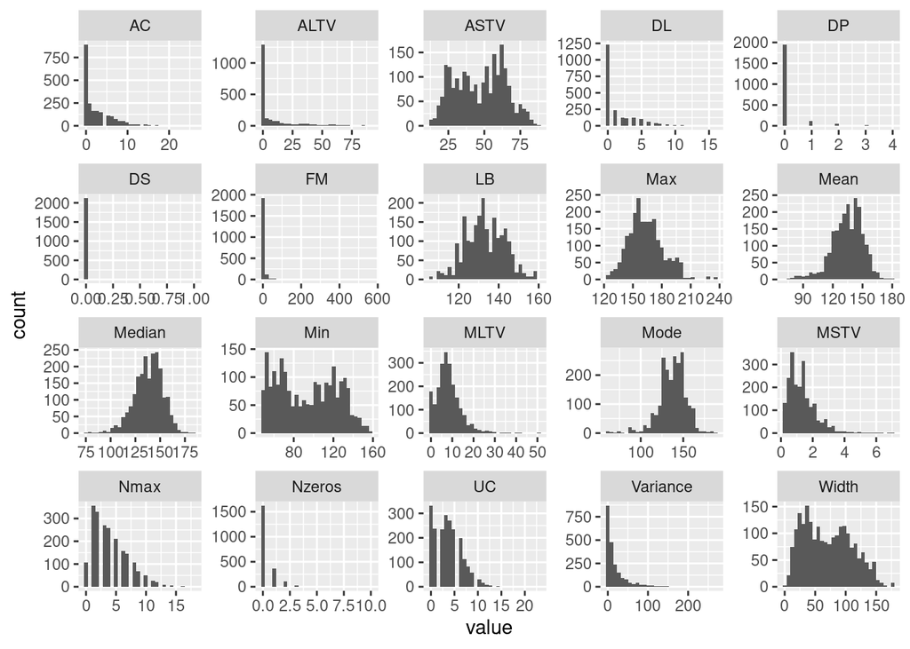

```r
# atributos numéricos (excluyendo las clasificaciones)
library(tidyr)
library(purrr)
library(ggplot2)

# plot
df %>%                                      #parto de la base de datos
  keep(is.numeric) %>%                      #me quedo con las variables numericas
  gather() %>%                              #reacomodo la base de datos
  ggplot(aes(value)) +                      #grafico
    facet_wrap(~ key, scales = "free") +    #uso facet para mostrar varios plots
    geom_histogram()                        #histogramas
```

Otro análisis esploratorio que podría ser útil es evaluar la distribución de cada variable pero ahora en relación a la clasificación de los fetos. Esto nos permitirïa evaluar *a priori* si alguna variable puede tener más útilidad que otra a la hora de discriminar los tipos de fetos.

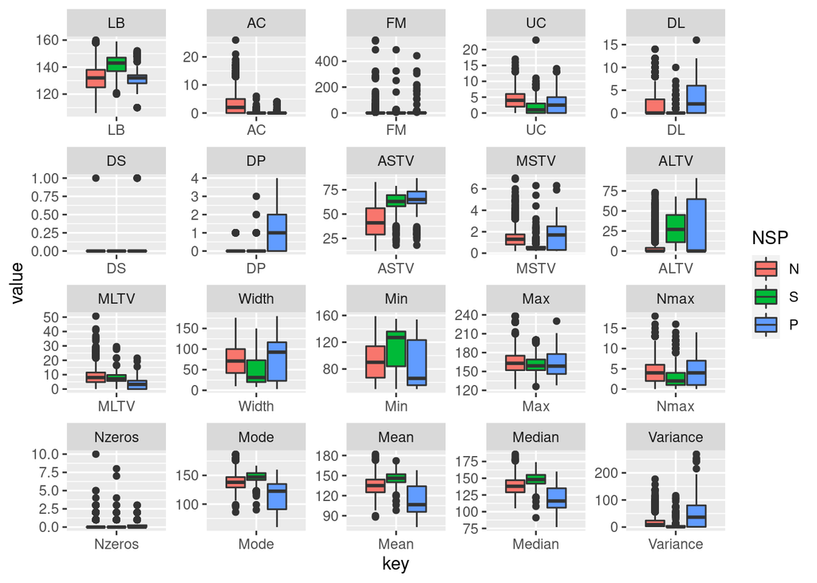

```r
df%>%
  gather('key','value',-NSP, factor_key = T)%>%   #acomodo la BD dejando NSP como factor
  ggplot(aes(x=key,y=value, fill=NSP)) +          #grafico por factores
    facet_wrap(~ key, scales = "free") +          #uso facet para mostrar varios plots
    geom_boxplot()
```

Adicionalmente podemos evaluar la multicolinealidad entre las variables. Este análisis nos permitiría eliminar variables que sean muy correladas entre sí para evitar redundancia en los modelos que ajustemos posteriormente.

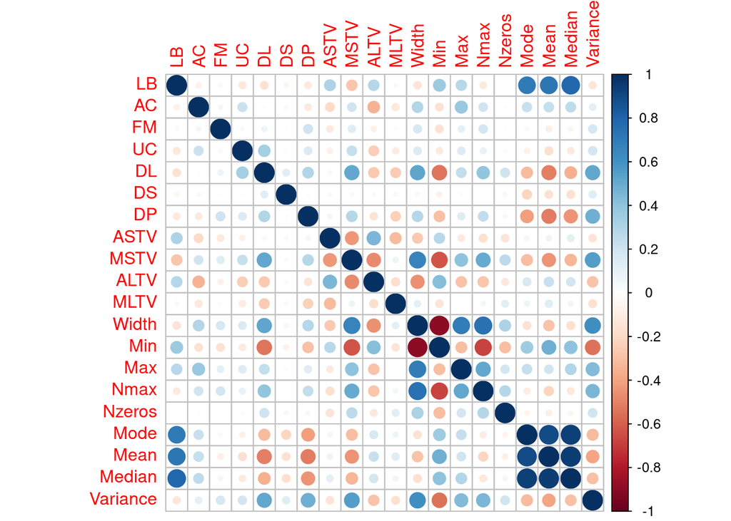

```r
library(caret)

df%>%
  keep(is.numeric)%>%     #filtro los atributos numéricos
  cor()%>%                #aplico un análisis de correlación
  corrplot::corrplot()    #grafico la matriz de correlación resultante
```

Vemos que hay ciertas variables que tienen una correlación alta entre ellas (|r|>0.7). Podemos filtrarlas

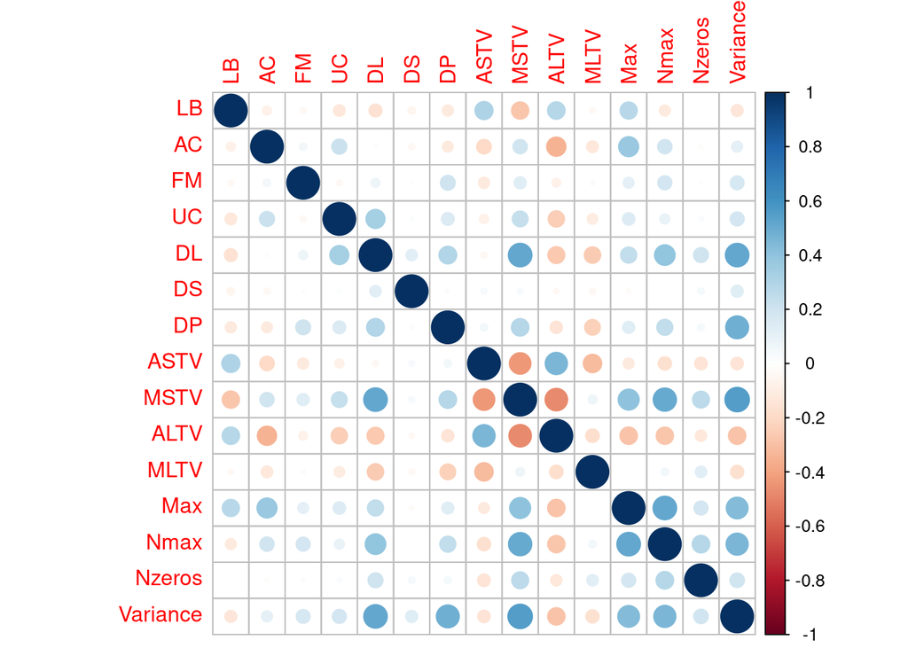

```r
#obtengo los atributos que cumplen con la condición de corte
a<-df%>%
  keep(is.numeric)%>%
  cor()%>%
  findCorrelation(cutoff = 0.7)

#vuelvo a hacer el análisis de correlación sin esas variables
df[-a]%>%
  keep(is.numeric)%>%     #filtro los atributos numéricos
  cor()%>%                #aplico un análisis de correlación
  corrplot::corrplot()
```

Como podemos ver la multicolealidad se ha reducido luego del análisis de correlación y el filtrado.

# 5 Análisis de Componentes Principales (PCA)

Podemos aplicar un análisis de componentes principales a las variables filtradas en el punto anterior con el fin de reducir la dimensionalidad y extraer carateristicas de los datos (Gironés Roig 2017). El algoritmo PCA reduce la dimensionalidad mediante una transformación lineal que escoge un nuevo sistema de coordenadas para el conjunto original de datos, en el cual la varianza de mayor tamaño del conjunto de datos se recoge en el primer eje (llamado primer componente principal), la segunda varianza más grande en el segundo eje (segundo componente principal y así sucesivamente (Gironés Roig 2017).

Comenzamos aplicamos un algoritmo PCA usando la función *princomp* (existen otras funciones para esto, como *rda* del paquete Vegan) a la base de datos actualizada en función del filtrado que hicimos en el punto anterior y luego. Para este análisis voy a eliminar algunas variables que tienen distribuciones que pueden complicar el PCA (ver sección “Análisis exploratorio”). NPS no la uso para el PCA (luego la utilizaré en el biplot).

```r
df_pca<-subset(df, select = -c(a,DP,DS,FM,DL,Nzeros, NSP))
pca<-princomp(df_pca)

#observamos el resultado
summary(pca)
```

```
## Importance of components:
##                            Comp.1     Comp.2     Comp.3      Comp.4     Comp.5
## Standard deviation     31.6049324 20.4919742 16.2009410 12.76707913 7.76354567
## Proportion of Variance  0.5112981  0.2149473  0.1343522  0.08343485 0.03085209
## Cumulative Proportion   0.5112981  0.7262454  0.8605976  0.94403245 0.97488455
##                            Comp.6      Comp.7      Comp.8      Comp.9
## Standard deviation     5.24274516 2.986460641 2.648403344 2.300148096
## Proportion of Variance 0.01406961 0.004565391 0.003590316 0.002708171
## Cumulative Proportion  0.98895415 0.993519544 0.997109860 0.999818031
##                             Comp.10
## Standard deviation     0.5962340671
## Proportion of Variance 0.0001819692
## Cumulative Proportion  1.0000000000
```

Para analizar la varianza capturada por cada uno de los componentes podemos crear un *screeplot*. Adicionalmente podemos aplicar la regla de *broken stick* para determinar el número de componentes a retener. Este método sugiere seleccionar aquellos componentes principales cuyo valor de inercia sea mayor que el predicho por el modelo *broken stick* (Legendre and Legendre 2012).

```r
library(vegan)
```

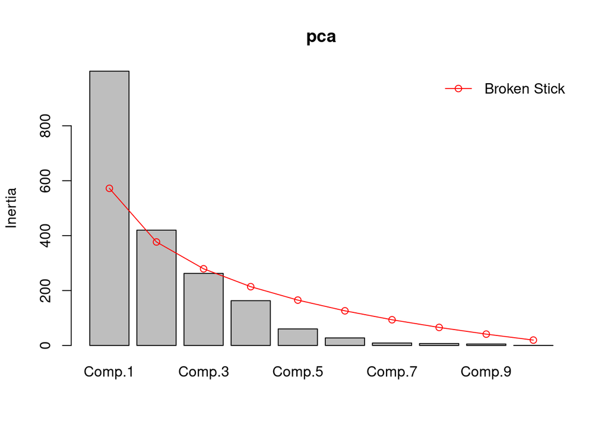

```r
screeplot(pca, bstick = T)
```

Como podemos ver, el método de *broken stick* sugiere retener los primeros 2 componentes principales. Podemos ver del *summary* que el porcentaje de varainza acumulada por estos dos componentes es de más del 70%.

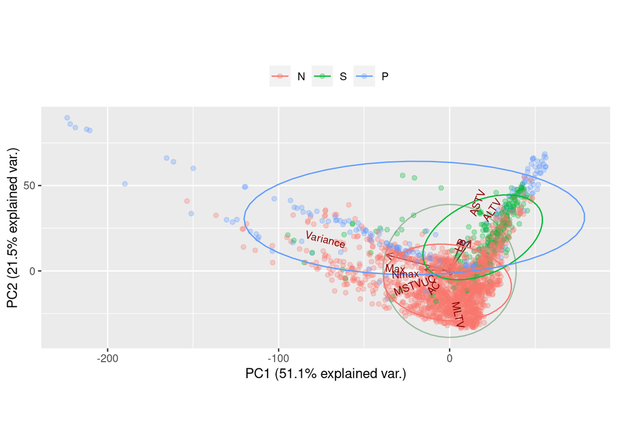

```r
#library(devtools)
#install_github("https://github.com/vqv/ggbiplot")
library(ggbiplot)

#realizo el biplot utilizando la variable NSP como factor

ggbiplot(pca, obs.scale = 1, var.scale = 1,
         groups = df$NSP, ellipse = TRUE,
         circle = TRUE, alpha = 0.3, varname.adjust = 3) +
  scale_color_discrete(name = '') +
  theme(legend.direction = 'horizontal', legend.position = 'top')
```

Podemos ver que el biplot nos muestra el porcentaje de varianza explicada por cada uno de los componentes y como se distribuyen en el nuevo espacio n-dimensional las observaciones de mi base de datos (que correponde a las cardiotocografías). Si bien el patrón de separación de los 3 grupos de fetos no es muy claro, podemos decir que el PC2 podría estar separando aquellos fetos normales de los patológicos. El biplot también nos indica las variables que están más correlacionadas con cada uno de los componentes (largo de la flecha). Pero esta información también podemos verla en los *loadings* del PCA.

```r
pca$loadings
```

```
##
## Loadings:
##          Comp.1 Comp.2 Comp.3 Comp.4 Comp.5 Comp.6 Comp.7 Comp.8 Comp.9 Comp.10
## LB               0.172  0.342  0.101  0.909
## AC                                           0.226  0.897 -0.359
## UC                                                  0.338  0.925  0.135
## ASTV      0.171  0.649  0.165 -0.704 -0.106 -0.116
## MSTV                                                                     0.997
## ALTV      0.290  0.646 -0.107  0.673 -0.173
## MLTV            -0.104                      -0.956  0.249
## Max      -0.343         0.856  0.187 -0.317
## Nmax                                                      -0.118  0.981
## Variance -0.873  0.343 -0.326         0.103
##
##                Comp.1 Comp.2 Comp.3 Comp.4 Comp.5 Comp.6 Comp.7 Comp.8 Comp.9
## SS loadings       1.0    1.0    1.0    1.0    1.0    1.0    1.0    1.0    1.0
## Proportion Var    0.1    0.1    0.1    0.1    0.1    0.1    0.1    0.1    0.1
## Cumulative Var    0.1    0.2    0.3    0.4    0.5    0.6    0.7    0.8    0.9
##                Comp.10
## SS loadings        1.0
## Proportion Var     0.1
## Cumulative Var     1.0
```

De esta información vemos que las variables ASTV (“percentage of time with abnormal short term variability”) y ALTV (“percentage of time with abnormal long term variability”) son las más correlacionadas con el PC2 y entonces las que podrían estar ayudando más a separar aquellos fetos normales de los patológicos. La variable MLTV (“mean value of long term variability”) si bien tiene una correlación no muy alta con el segundo componente, es la única que muestra una correlación negativa; por lo que también puede ser útil para separar estos grupos. La variable VARIANCE es la más correlacionada con el primer componente principal, por lo que podría ser importante para la separación entre los fetos patológicos de los sospechosos. Como esta correlación es negativa, se interpreta que a mayores valores de VARIANCE, más nos alejamos del 0 sobre el PC1. Esto indica que los fetos patológicos muestran valores mayores de esta variable; mientras que los sospechosos tienen valores menores.

Como conclusión podemos decir que el Análsis de Componentes Principales puede ser útil en aquellos casos en los que se intente reducir la dimensionalidad de un conjunto de variables que se sospechan explicatorias de cierto proceso. Esto facilita la interpretación de las relaciones y permite identificar aquellas variables más influyentes. Es una técnica muy poderosa y muy utilizada en el ámbito de la ciencia de datos.

# 6 Árboles de decisión

Los árboles de decisión son un modelo de minería de datos que intenta subdividir el espacio de datos de entrada para generar regiones disjuntas, de forma que todos los elementos que pertenezcan a una misma región sean de la misma clase, la cual es utilizada como representante o clase de dicha región (Gironés Roig 2017). Si una región contiene datos de diferentes clases es subdividida en regiones más pequeñas siguiendo el mismo criterio, hasta particionar todo el espacio de entrada en regiones disjuntas que solamente contienen elementos de una misma clase (Gironés Roig 2017). Aquí aplicaremos un árbol de decisión a los datos de cardiotocogramas para encontrar reglas que logren clasificar correctamente los fetos en sus tres clases (normal, sospechoso y patológico) en función de las variables que disponemos. Voy a partir de la base de datos filtrada por el análisis exploratorio y que se usó para correr el análisis de PCA (ver sección anterior).  
Comenzamos reordenando los datos al azar y separando los datos en un set de entreanmiento y otro de test.

```r
set.seed(5813)

#filtro las variables que usaré
df_tree<-subset(df, select = -c(a,DP,DS,FM,DL,Nzeros))

#ordeno los datos al azar
df_tree<-df_tree[sample(nrow(df_pca)),]

#separo las variables predictoras de la de clasificación
X<-df_tree[-11]
Y<-df_tree[11]$NSP

#separo en set de entrenamiento y test
indexes = sample(1:nrow(df_tree), size=floor((3/4)*nrow(df_tree)))
trainX<-X[indexes,]
trainY<-Y[indexes]
testX<-X[-indexes,]
testY<-Y[-indexes]
```

Podemos controlar el parámetro “minCases” dentro de “control” de la función C50.0 que controla el número mínimo de muestras a colocar en cada división del árbol. A medida que se aumenta, el árbol se hace menos profundo. Podemos probar diferentes valores y evaluar su nivel de *accuracy*.

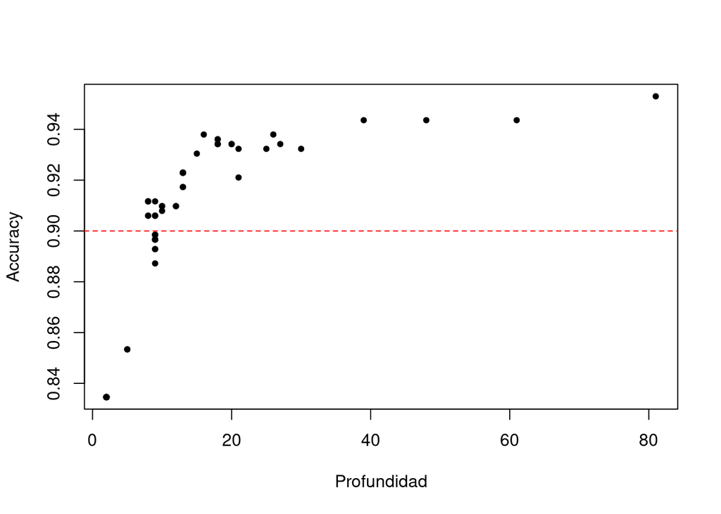

```r
if(!require(C50)){
    install.packages('C50',repos='http://cran.es.r-project.org')
    require(C50)
}

if(!require(caret)){
    install.packages('caret')
    require(caret)
}

set.seed(5813)

#creo vectores donde alojar los valores de accuracy y de tamaño del árbol
acc<-c()
prof<-c()

#armo un loop for para probar valores de 1 a 50
for (i in seq(1,100)) {
  #creo el modelo
  model <- C50::C5.0(trainX,
                     trainY,
                     rules=F,
                     control=C5.0Control(noGlobalPruning = T,
                                         minCases = i))
  #calculo los predichos
  predicted <- predict(model, testX, type="class" )
  #guardo el tamaño
  prof[i]<-model$size
  #guardo el accuracy
  acc[i]<-confusionMatrix(predicted, testY)$overall[1]
}

#guardo los datos en un data frame
models<-data.frame(acc,prof, "minCases"=seq(1,100))

#grafico la variación del accuracy en función de la profundidad del árbol
{plot(models$prof,models$acc, ylab = "Accuracy", xlab="Profundidad", pch=20)
abline(h=0.9, col="red", lty=20)}
```

La linea punteada roja separa aquellos árbooles que tuvieron *accurary* mayor o igual a 0.9. De ellos, podemos elegir aquel que tenga menor profundidad. Así habremos elegido el modelo más simple con el nivel de *accuracy* que establecimos como aceptable. Creamos la matriz de confusión de ese modelo y calculamos su valor de *accuray*. En este caso, activaremos la opción de *prunning* para eliminar las hojas del árbol que menos contribuyen a la clasificación.

```r
# busco el modelo con menor profundidad de entre los que tengan accuracy >= 0.9 para saber el valor del paŕametro minCases
print(subset((models[models$acc>=0.9,]), subset = prof==min(prof))[1,])
```

```
##          acc prof minCases
## 46 0.9116541    8       46
```

```r
# creo el modelo el valor de minCases del punto anterior per esta vez con la opción de prunning activada
set.seed(5813)
model <- C50::C5.0(trainX,trainY, rules=F, control=C5.0Control(noGlobalPruning = F, minCases = 46))

# usamos el modelo para clasificar el set de prueba
predicted_model <- predict(model, testX, type="class" )

# creo la matriz de confusion
conf.matrix<-confusionMatrix(predicted_model, testY)
conf.matrix$table
```

```
##           Reference
## Prediction   N   S   P
##          N 423  21   8
##          S   9  36   2
##          P   2   3  28
```

```r
# mostramos la precisión del árbol
print(sprintf("La precisión del árbol es: %.2f %%",conf.matrix$overall[1]*100))
```

```
## [1] "La precisión del árbol es: 91.54 %"
```

Ahora podemos graficar el árbol.

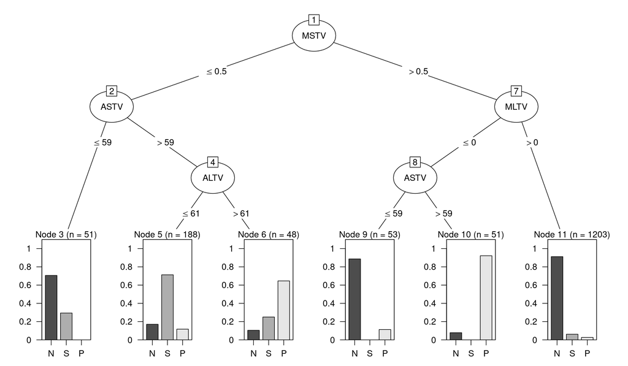

```r
plot(model)
```

A continuación podemos mostrar las reglas.

```r
model <- C50::C5.0(trainX,trainY, rules=T, control=C5.0Control(noGlobalPruning = F, minCases = 46))
summary(model)
```

```
##
## Call:
## C5.0.default(x = trainX, y = trainY, rules = T, control
##  = C5.0Control(noGlobalPruning = F, minCases = 46))
##
##
## C5.0 [Release 2.07 GPL Edition]      Wed Jan 13 17:18:04 2021
## -------------------------------
##
## Class specified by attribute `outcome'
##
## Read 1594 cases (11 attributes) from undefined.data
##
## Rules:
##
## Rule 1: (1101/86, lift 1.2)
##  ASTV <= 59
##  ->  class N  [0.921]
##
## Rule 2: (1203/106, lift 1.2)
##  MSTV > 0.5
##  MLTV > 0
##  ->  class N  [0.911]
##
## Rule 3: (188/54, lift 4.8)
##  ASTV > 59
##  MSTV <= 0.5
##  ALTV <= 61
##  ->  class S  [0.711]
##
## Rule 4: (52/4, lift 10.5)
##  ASTV > 59
##  MLTV <= 0
##  ->  class P  [0.907]
##
## Rule 5: (48/17, lift 7.4)
##  ASTV > 59
##  MSTV <= 0.5
##  ALTV > 61
##  ->  class P  [0.640]
```

[output cut: 14 more lines]

```
##    ----  ----  ----
##    1180    32     9    (a): class N
##      89   134    12    (b): class S
##      38    21    79    (c): class P
##
##
##  Attribute usage:
##
##   90.28% MSTV
##   87.08% ASTV
##   78.73% MLTV
##   14.81% ALTV
##
##
## Time: 0.0 secs
```

Podemos ver que una regla con un lift alto es la número 4 que se interpreta de la siguiente manera: si una muestra tiene un valor de ASTV (*“percentage of time with abnormal short term variability”*) mayor a 59 y un MLTV (*“mean value of long term variability”*) menor o igual a cero, entonces el fet tiene altas probabilidades de ser clasificado como patológico. Esta regla es importante ya que no permite discriminar a los fetos patológicos. Otra regla importante es la 3 que permite clasificar a los fetos en la clase sospechosos. Esta regla sería: si la muestra tiene un ASTV mayor a 59, un MSTV menor o igual a 0.5 y ALTV (*“percentage of time with abnormal long term variability”*), entonces el feto tiene altas probabilidades de ser sospechoso).

Los árboles de decisión son herramientas muy valiosas como técnicas de clasificación y relativamente versátiles, lo que permite adaptarlos para poder incrementar la precisión del algoritmo. En este caso se ha utilizado los *settings* avanzados del paquete para poder llegar a un árbol relativamente sencillo y con buen nivel de *accuracy*.

# 7 Método no supervisado (*Hierarchical Clustering*)

Voy a aplicar un algoritmo conocido como Hierarchical Clustering. Este es un método alternativo al k-means que no requiere de la identificación a priori de clusters como si es necesario con la técnica de k-means. Otras de las ventajas que tiene es que permite mostrar el ordenamiento en forma de dendrograma (esto agrega una visualización extra que puede ayudar a interpretar los datos). Como se explica en los apuntes teóricos, este tipo de agrupamiento tiene dos grandes versiones: agglomerative clustering (AGNES) y divisive hierarchical clustering (DIANA). El primero trabaja de manera bottom-up, es decir que cada objeto es considerado inicialmente como un cluster formado por un solo elemento y en cada paso el algoritmo va uniendo los clusters que sean más parecidos. El segundo trabaja de manera top-down, es decir que se comienza con la asumpción de que todos los elementos forman un gran cluster y a cada paso este cluster se va dividiendo en otros más pequeños.

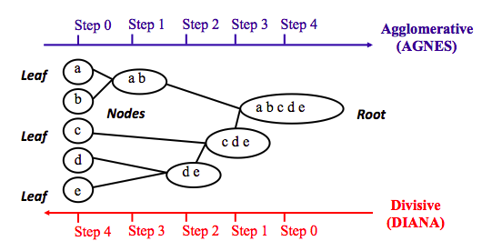

Como se vio también en la teoría, estos algortimos pueden tener diferencias en cómo miden la similitud entre dos cluster. Las opciones son: maximum linkage (se calculan las distancias entre los elementos del cluster 1 y 2 y se toma el valor mayor), minimum linkage (se calculan las distancias entre los elementos del cluster 1 y 2 y se toma el valor menor), mean linkage (se calculan las distancias entre los elementos del cluster 1 y 2 y se toma el valor medio), centroid linkage (se usan las distancias entre los centroides de los clusters) y método Ward (minimiza la varianza total dentro del grupo. En cada paso, se fusiona el par de grupos con una distancia mínima entre grupos). Como puede esperarse, la clasificación resultante dependerá del método utilizado. AGNES permite calcular un coeficiente de aglomeración que indica qué tanto agrupamiento se encontró en los datos (valores cercanos a 1 indican mayor agrupamiento).

```r
if(!require(cluster)){
    install.packages('cluster',repos='http://cran.es.r-project.org')
    require(cluster)
}

#AGNES
library(purrr)
set.seed(2500)

#datos
df_clust<-subset(df, select = -c(a,DP,DS,FM,DL,Nzeros,NSP))

#listo los metodos de linkage que usaré
m <- c( "average", "single", "complete", "ward")
names(m) <- c( "average", "single", "complete", "ward")

#creo una función para computar el coeficiente para cada método y que me muestre el coeficiente de aglomeración

ac <- function(x, distancia) {
  if (distancia=="euclidea") {
    ag<-agnes(df_clust, method = x, diss = F, metric = "euclidean", stand = T)$ac
  } else {
    if (distancia=='manhattan') {
      ag<-agnes(df_clust, method = x, diss = F, metric = "manhattan", stand = T)$ac
    }
  }
  return(cat('Los valores para', distancia, 'y método', x, 'son: ', ag, "\n"))
}

#aplico la función para distancia euclideana
l1<-pmap(list(m,'euclidea'), ac)
```

```
## Los valores para euclidea y método average son:  0.9183812
## Los valores para euclidea y método single son:  0.7873325
## Los valores para euclidea y método complete son:  0.9387567
## Los valores para euclidea y método ward son:  0.9899789
```

```r
#aplico la función para distancia de manhattan
l2<-pmap(list(m,'manhattan'), ac)
```

```
## Los valores para manhattan y método average son:  0.9026416
## Los valores para manhattan y método single son:  0.8113258
## Los valores para manhattan y método complete son:  0.9473569
## Los valores para manhattan y método ward son:  0.9926873
```

Vemos que para las dos distancias utilizadas, el método de Ward es el que arroja mayor valor de coeficiente de aglomeración, por lo que utilizaremos ese método. Ploteamos los dendrogramas separando en 3 cluster dado que a priori sabemos que existen 3 clases (esto en condiciones normales no lo sabríamos y por eso estamos usando un método no supervisado).

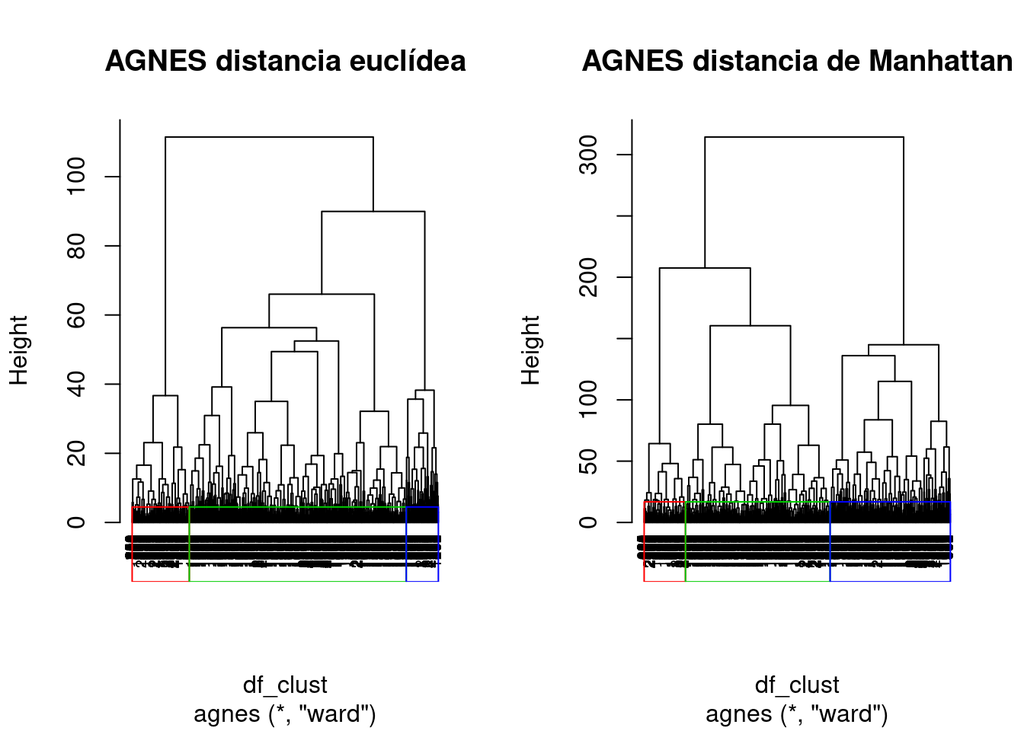

```r
# AGNES
set.seed(2500)
hc_eucl<-agnes(df_clust, method = 'ward', diss = F, metric = "euclidean", stand = T, keep.data = T)
hc_manh<-agnes(df_clust, method = 'ward', diss = F, metric = "manhattan", stand = T, keep.data = T)

# Ploteo los dos dendrogramas
par(mfrow=c(1,2))
pltree(hc_eucl, cex = 0.6, hang = -1, main = "AGNES distancia euclídea")
rect.hclust(hc_eucl, k = 3, border = 2:5)
pltree(hc_manh, cex = 0.6, hang = -1, main = "AGNES distancia de Manhattan")
rect.hclust(hc_manh, k = 3, border = 2:5)
```

Adicionalmente podemos realizar un scatterplot utilizando la librería factoextra.

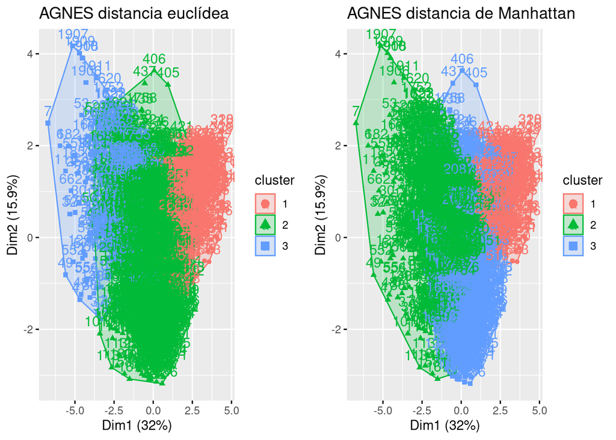

```r
if(!require(factoextra)){
    install.packages('factoextra',repos='http://cran.es.r-project.org')
    require(factoextra)
}

if(!require(gridExtra)){
    install.packages('gridExtra',repos='http://cran.es.r-project.org')
    require(gridExtra)
}

#corto los dendrogramas en 3
agnes_eucl <- cutree(hc_eucl, k = 3)
agnes_manh <- cutree(hc_manh, k = 3)

#plot
p1<-fviz_cluster(list(data = df_clust, cluster = agnes_eucl), main = "AGNES distancia euclídea")
p2<-fviz_cluster(list(data = df_clust, cluster = agnes_manh), main= "AGNES distancia de Manhattan")

require(gridExtra)
grid.arrange(grobs=list(p1,p2),ncol=2)
```

Como podemos ver los porcentajes de varianza explicada son relativamente bajos para ambos modelos, y similares entre ellos. La dimensión 1 contribuye con la mayor varianza explicada y visualmente puede verse que los grupos se separan más en esta dimensión, aunque esta separación no es muy notorio. Ya que conocemos el valor de la clase para cada muestra podemos evaluar la *performance* de ambos algoritmos de *clustering*.

```r
#hago una correspondencia entre las clases de los datos originales y los grupos identificados por los algoritmos (me baso en el tamaño de las muestras correspondiente a cada caso)
table(df$NSP)
```

```
##
##    N    S    P
## 1655  295  176
```

```r
table(agnes_eucl)
```

```
## agnes_eucl
##    1    2    3
##  397 1506  223
```

```r
table(agnes_manh)
```

```
## agnes_manh
##    1    2    3
##  287  835 1004
```

```r
# para dist euclidea
agnes_eucl[agnes_eucl==1]<-"S"
agnes_eucl[agnes_eucl==2]<-"N"
agnes_eucl[agnes_eucl==3]<-"P"
agnes_eucl<-factor(agnes_eucl, levels = c('N','S','P'))

# para dist de Manhattan
agnes_manh[agnes_manh==1]<-"P"
agnes_manh[agnes_manh==2]<-"S"
agnes_manh[agnes_manh==3]<-"N"
agnes_manh<-factor(agnes_manh, levels = c('N','S','P'))


# creo las matrices de confusion
conf.matrix_eucl<-confusionMatrix(agnes_eucl, df$NSP)
conf.matrix_eucl$table
```

```
##           Reference
## Prediction    N    S    P
##          N 1355  104   47
##          S  155  183   59
##          P  145    8   70
```

```r
conf.matrix_manh<-confusionMatrix(agnes_manh, df$NSP)
conf.matrix_manh$table
```

```
##           Reference
## Prediction   N   S   P
##          N 841 149  14
##          S 716  15 104
##          P  98 131  58
```

```r
# mostramos la precisión
print(sprintf("Clustering basado en dist. euclídea es: %.2f %%",conf.matrix_eucl$overall[1]*100))
```

```
## [1] "Clustering basado en dist. euclídea es: 75.63 %"
```

```r
print(sprintf("Clustering basado en dist. Manhattan es: %.2f %%",conf.matrix_manh$overall[1]*100))
```

```
## [1] "Clustering basado en dist. Manhattan es: 42.99 %"
```

Como podemos ver ambos algoritmos tienen un *accuracy* bajo, aunque el basado en distancia euclídea muestra una performance mejor que el que usa distancia de Manhattan.

# 8 Método supervisado (K-Nearest Neighbors)

El algoritmo K-Nearest Neighbors (KNN) reconoce patrones en los datos sin un aprendizaje específico, simplemente midiendo la distancia entre grupos de datos. Se trata de uno de los algoritmos más simples y robustos de aprendizaje automático. En realidad el algoritmo puede usarse tanto para clasificar como para pronosticar mediante regresión, pero aquí veremos solo la forma de clasificación. Como se calcula la similitud con respecto a la distancia, debemos tener en mente que las distancias entre variables deben ser comparables. Para aplicar este algoritmo es importante normalizar los datos, re-escalar todas las variables para que las distancias sean equiparables.

```r
# datos
df_knn<-subset(df, select = -c(a,DP,DS,FM,DL,Nzeros,NSP))
# escalado
df_knn<-scale(df_knn)

# separamos los datos en train y test
set.seed(123)
dat.d <- sample(1:nrow(df_knn),size=nrow(df_knn)*0.75,replace = FALSE)

trainX <- df_knn[dat.d,]
testX <- df_knn[-dat.d,]

# hago lo mismo con la variable clasificatoria
trainY<-df$NSP[dat.d]
testY<-df$NSP[-dat.d]
```

Con estos datos podemos contruir el modelo. Algo que es necesario para poder correr el algoritmo de KNN es el parámetro “k”. Este parámetro se utiliza para seleccionar los “k” elementos más cercanos (con menor distancia, según la función que se use). Una de las maneras de encontrar el valor de k es calcular la raíz cuadrada del total de observaciones en el set de datos de entrenamiento. Vamos a usar ese valor, en principio.

```r
if(!require(class)){
    install.packages('class',repos='http://cran.es.r-project.org')
    require(class)
  }

# k
k<-round(sqrt(NROW(trainX)),0)

# KNN
set.seed(123)
knn <- knn(train=trainX, test=testX, cl=trainY, k=k)

# evaluo la performance del modelo
confusionMatrix(table(knn, testY))
```

```
## Confusion Matrix and Statistics
##
##    testY
## knn   N   S   P
##   N 397  39  25
##   S   9  36   9
##   P   1   0  16
##
## Overall Statistics
##
##                Accuracy : 0.844
##                  95% CI : (0.8103, 0.8738)
##     No Information Rate : 0.765
##     P-Value [Acc > NIR] : 4.711e-06
##
##                   Kappa : 0.5121
##
##  Mcnemar's Test P-Value : 8.375e-11
##
## Statistics by Class:
##
##                      Class: N Class: S Class: P
## Sensitivity            0.9754  0.48000  0.32000
## Specificity            0.4880  0.96061  0.99793
## Pos Pred Value         0.8612  0.66667  0.94118
## Neg Pred Value         0.8592  0.91841  0.93398
## Prevalence             0.7650  0.14098  0.09398
## Detection Rate         0.7462  0.06767  0.03008
## Detection Prevalence   0.8665  0.10150  0.03195
## Balanced Accuracy      0.7317  0.72031  0.65896
```

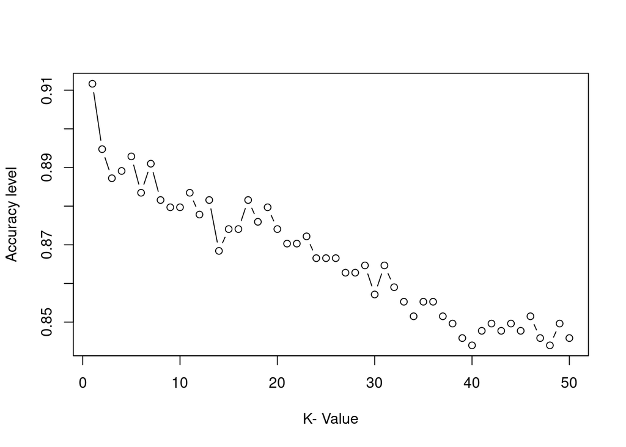

```r
set.seed(123)

#creo una función para probar valores de k desde 1 hasta 50
k.opt<-c()
for (i in 1:50){
  #ajusto knn
  knn.mod <- knn(train=trainX, test=testX, cl=trainY, k=i)
  #calculo accuracy
  k.opt[i]=confusionMatrix(table(knn.mod, testY))$overall[1]
  }

# grafico
plot(k.opt, type="b", xlab="K- Value",ylab="Accuracy level")
```

```r
set.seed(123)
knn3 <- knn(train=trainX, test=testX, cl=trainY, k=3)
confusionMatrix(table(knn3, testY))
```

```
## Confusion Matrix and Statistics
##
##     testY
## knn3   N   S   P
##    N 387  28   5
##    S  15  45   5
##    P   5   2  40
##
## Overall Statistics
##
##                Accuracy : 0.8872
##                  95% CI : (0.8572, 0.9128)
##     No Information Rate : 0.765
##     P-Value [Acc > NIR] : 5.227e-13
##
##                   Kappa : 0.6956
##
##  Mcnemar's Test P-Value : 0.1567
##
## Statistics by Class:
##
##                      Class: N Class: S Class: P
## Sensitivity            0.9509  0.60000  0.80000
## Specificity            0.7360  0.95624  0.98548
## Pos Pred Value         0.9214  0.69231  0.85106
## Neg Pred Value         0.8214  0.93576  0.97938
## Prevalence             0.7650  0.14098  0.09398
## Detection Rate         0.7274  0.08459  0.07519
## Detection Prevalence   0.7895  0.12218  0.08835
## Balanced Accuracy      0.8434  0.77812  0.89274
```

Otra alternativa es aplicar un análisis de componentes principales (PCA) previo a la implementación del algoritmo KNN para reducir la dimensionalidad de los datos y ver si eso mejora el la performance.

```r
# datos
df_knn<-subset(df, select = -c(a,DP,DS,FM,DL,Nzeros,NSP))
# escalado
df_knn<-scale(df_knn)

# PCA. Tomamos los 3 primers componentes principales
pca <- princomp(df_knn, cor=T)
pc.comp <- pca$scores
pc.comp1 <- pc.comp[,1]
pc.comp2 <- pc.comp[,2]
pc.comp3 <- pc.comp[,3]
X<-cbind(pc.comp1,pc.comp2, pc.comp3)

# separamos los datos en train y test
set.seed(155)
dat.d <- sample(1:nrow(df_knn),size=nrow(df_knn)*0.75,replace = FALSE)

trainX <- X[dat.d,]
testX <- X[-dat.d,]

# hago lo mismo con la variable clasificatoria
trainY<-df$NSP[dat.d]
testY<-df$NSP[-dat.d]
```

Pruebo la optimización antteriormente aplicada para encntrar el valor de K.

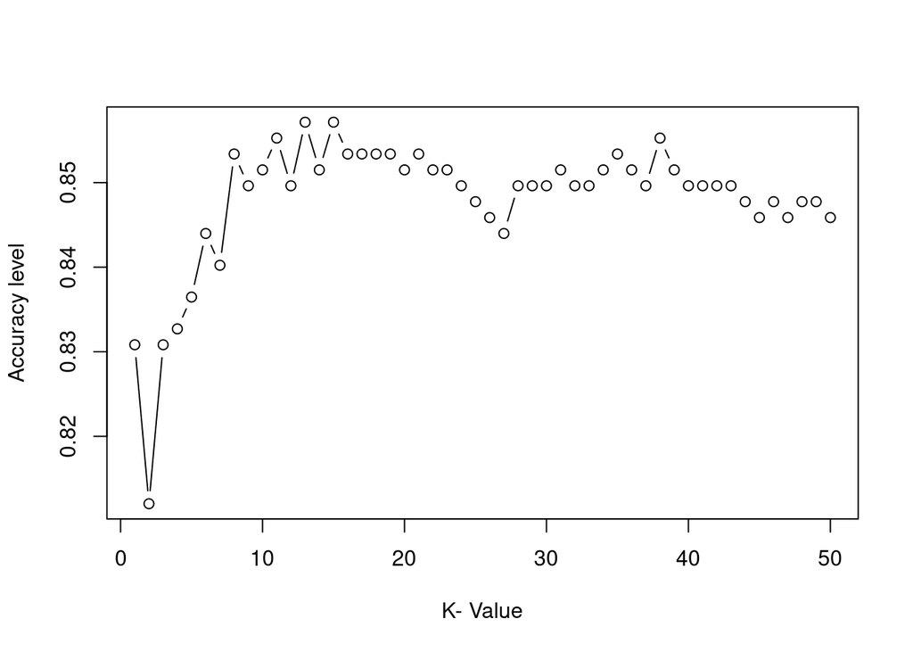

```r
set.seed(123)

#creo una función para probar valores de k desde 1 hasta 50
k.opt<-c()
for (i in 1:50){
  #ajusto knn
  knn.mod <- knn(train=trainX, test=testX, cl=trainY, k=i)
  #calculo accuracy
  k.opt[i]=confusionMatrix(table(knn.mod, testY))$overall[1]
  }

# grafico
plot(k.opt, type="b", xlab="K- Value",ylab="Accuracy level")
```

En este caso el mejor valor de k es 15. Ajusto el modelo KNN con este valor de k y evaluo su performance.

```r
knn_pca <- knn(train=trainX, test=testX, cl=trainY, k=15)

# evaluo la performance del modelo
confusionMatrix(table(knn_pca, testY))
```

```
## Confusion Matrix and Statistics
##
##        testY
## knn_pca   N   S   P
##       N 396  33  19
##       S  14  47   8
##       P   3   0  12
##
## Overall Statistics
##
##                Accuracy : 0.8553
##                  95% CI : (0.8225, 0.8841)
##     No Information Rate : 0.7763
##     P-Value [Acc > NIR] : 3.032e-06
##
##                   Kappa : 0.5542
##
##  Mcnemar's Test P-Value : 5.051e-06
##
## Statistics by Class:
##
##                      Class: N Class: S Class: P
## Sensitivity            0.9588  0.58750  0.30769
## Specificity            0.5630  0.95133  0.99391
## Pos Pred Value         0.8839  0.68116  0.80000
## Neg Pred Value         0.7976  0.92873  0.94778
## Prevalence             0.7763  0.15038  0.07331
## Detection Rate         0.7444  0.08835  0.02256
## Detection Prevalence   0.8421  0.12970  0.02820
## Balanced Accuracy      0.7609  0.76941  0.65080
```

Vemos que el valor de *accuracy* es de 0.85, menor al valor encontrado para el KNN ajustado con los datos sin reducir mediante PCA. Si bien en este caso la aplicación de PCA no mejoró la performance del modelo, esta técnica puede ayudar cuando el número de variables es mucho mayor al caso de estudio aquí presentado. KNN tiende a funcionar mejor cuando el número de variables no es muy grande, por lo que para estos casos podría ser muy útil reducir la dimensionalidad de los datos mendiante PCA.

# Referencias

Ayres-de-Campos, Diogo, Joao Bernardes, Antonio Garrido, Joaquim Marques-de-Sa, and Luis Pereira-Leite. 2000. “SisPorto 2.0: a program for automated analysis of cardiotocograms.” *Journal of Maternal-Fetal Medicine* 9 (5). Taylor & Francis: 311–18.

Gironés Roig, Jordi. 2017. “Minería de datos: modelos y algoritmos.” *Minería de Datos*. Editorial UOC, 1–273.

Legendre, Pierre, and Loic F J Legendre. 2012. *Numerical ecology*. Vol. 20. Elsevier.

Sahin, Hakan, and Abdulhamit Subasi. 2015. “Classification of the cardiotocogram data for anticipation of fetal risks using machine learning techniques.” *Applied Soft Computing* 33. Elsevier: 231–38.